# CA2 - Investmnt Portfolio Fuzzy Expert System

This Notebook describes the fuzzy expert system and the output of the test cases for each rule block.

# Initialise

Prepare the environment and load the necessary libraries.

```r
rm(list=ls())
library(sets)
```

Set the universe

```r
sets_options("universe", seq(from = 0, to = 100, by = 1))
```

# Define Variables

Set the variables and liguistic terms for the input and output variables

```r
variables = set(
  age_input = fuzzy_variable(
    a_young = fuzzy_trapezoid(corners = c(-20, 0, 35, 45)),
    a_middle = fuzzy_trapezoid(corners = c(35, 45, 55, 65)),
    a_old = fuzzy_trapezoid(corners = c(55, 65, 100, 120))
  ),

  income_input = fuzzy_variable(
    i_low = fuzzy_trapezoid(corners = c(-20, 0, 40, 50)),
    i_medium = fuzzy_trapezoid(corners = c(40, 45, 75, 80)),
    i_high = fuzzy_trapezoid(corners = c(75, 80, 100, 120))
  ),

  risk_input = fuzzy_variable(
    r_low = fuzzy_trapezoid(corners = c(-20, 0, 20, 30)),
    r_medium = fuzzy_trapezoid(corners = c(20, 30, 40, 50)),
    r_high = fuzzy_trapezoid(corners = c(40, 50, 100,120))
  ),

  current_property_input = fuzzy_variable(
    cp_low = fuzzy_trapezoid(corners = c(-20, 0, 90, 95)),
    cp_medium = fuzzy_trapezoid(corners = c(85, 90, 95, 100)),
    cp_high = fuzzy_trapezoid(corners = c(90, 95, 100, 120))
  ),

  current_stock_input = fuzzy_variable(
    cs_low = fuzzy_trapezoid(corners = c(-20, 0, 5, 7)),
    cs_medium = fuzzy_trapezoid(corners = c(4, 5, 10, 12)),
    cs_high = fuzzy_trapezoid(corners = c(8, 10, 100, 120))
  ),

  current_bank_input = fuzzy_variable(
    cb_low = fuzzy_trapezoid(corners = c(-20, 0, 5, 7)),
    cb_medium = fuzzy_trapezoid(corners = c(4, 5, 10, 12)),
    cb_high = fuzzy_trapezoid(corners = c(8, 10, 100, 120))
  ),

  property_output = fuzzy_variable(
    op_low = fuzzy_trapezoid(corners = c(-20,0, 30, 50)),
    op_medium = fuzzy_trapezoid(corners = c(30, 50, 70, 90)),
    op_high = fuzzy_trapezoid(corners = c(60, 70, 100, 120))
  ),

  stock_output = fuzzy_variable(
    os_low = fuzzy_trapezoid(corners = c(-20, 0, 5, 7)),
    os_medium = fuzzy_trapezoid(corners = c(4, 5, 10, 12)),
    os_high = fuzzy_trapezoid(corners = c(8, 10, 100, 120))
  ),

  bank_output = fuzzy_variable(
    ob_low = fuzzy_trapezoid(corners = c(-20, 0, 5, 7)),
    ob_medium = fuzzy_trapezoid(corners = c(4, 5, 10, 12)),
    ob_high = fuzzy_trapezoid(corners = c(8, 10, 100, 120))
  )
)
```

# Define Property Rules

```r
property_rules <-
  set(
    fuzzy_rule(age_input %is% a_young && income_input %is% i_low, property_output %is% op_low),
    fuzzy_rule(age_input %is% a_young && income_input %is% i_medium, property_output %is% op_medium),
    fuzzy_rule(age_input %is% a_young && income_input %is% i_high, property_output %is% op_high),
    fuzzy_rule(age_input %is% a_middle && (income_input %is% i_low || income_input %is% i_medium), property_output %is% op_low),
    fuzzy_rule(age_input %is% a_middle && income_input %is% i_high, property_output %is% op_medium),
    fuzzy_rule(age_input %is% a_old, property_output %is% op_low)
  )
```

# Construct the Property Fuzzy System

```r
property_system <- fuzzy_system(variables, property_rules)
print(property_system)
```

```
A fuzzy system consisting of 9 variables and 6 rules.

Variables:

current_bank_input(cb_low, cb_medium, cb_high)
current_stock_input(cs_low, cs_medium, cs_high)
bank_output(ob_low, ob_medium, ob_high)
stock_output(os_low, os_medium, os_high)
risk_input(r_low, r_medium, r_high)
age_input(a_young, a_middle, a_old)
property_output(op_low, op_medium, op_high)
income_input(i_low, i_medium, i_high)
current_property_input(cp_low, cp_medium, cp_high)

Rules:

age_input %is% a_young && income_input %is% i_low => property_output %is% op_low
age_input %is% a_young && income_input %is% i_high => property_output %is% op_high
age_input %is% a_young && income_input %is% i_medium => property_output %is% op_medium
age_input %is% a_middle && (income_input %is% i_low || income_input %is%  => property_output %is% op_low
    i_medium) => property_output %is% op_low
age_input %is% a_middle && income_input %is% i_high => property_output %is% op_medium
age_input %is% a_old => property_output %is% op_low
```

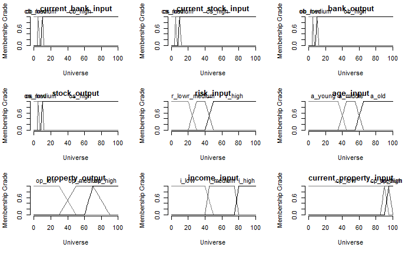

```r
plot(property_system)
```

# Define Stock Rules

```r
stock_rules <-
  set(
    fuzzy_rule(age_input %is% a_young && income_input %is% i_low && (risk_input %is% r_low || risk_input %is% r_medium), stock_output %is% os_low), #1
    fuzzy_rule(age_input %is% a_young && income_input %is% i_low && risk_input %is% r_high, stock_output %is% os_medium), #2
    fuzzy_rule(age_input %is% a_young && (income_input %is% i_medium || income_input %is% i_high) && risk_input %is% r_low, stock_output %is% os_low), #3
    fuzzy_rule(age_input %is% a_young && (income_input %is% i_medium || income_input %is% i_high) && risk_input %is% r_medium, stock_output %is% os_medium), #4
    fuzzy_rule(age_input %is% a_young && (income_input %is% i_medium || income_input %is% i_high) && risk_input %is% r_high, stock_output %is% os_high), #5
    fuzzy_rule(age_input %is% a_middle && income_input %is% i_low, stock_output %is% os_low), #6
    fuzzy_rule(age_input %is% a_middle && income_input %is% i_medium && (risk_input %is% r_low || risk_input %is% r_medium), stock_output %is% os_low), #7
    fuzzy_rule(age_input %is% a_middle && income_input %is% i_medium && risk_input %is% r_high, stock_output %is% os_medium), #8
    fuzzy_rule(age_input %is% a_middle && income_input %is% i_high && risk_input %is% r_low, stock_output %is% os_low), #9
    fuzzy_rule(age_input %is% a_middle && income_input %is% i_high && risk_input %is% r_medium, stock_output %is% os_medium), #10
    fuzzy_rule(age_input %is% a_middle && income_input %is% i_high && risk_input %is% r_high, stock_output %is% os_high), #11
    fuzzy_rule(age_input %is% a_old && (income_input %is% i_low || income_input %is% i_medium), stock_output %is% os_low), #12
    fuzzy_rule(age_input %is% a_old && income_input %is% i_high && (risk_input %is% r_low || risk_input %is% r_medium), stock_output %is% os_low), #13
    fuzzy_rule(age_input %is% a_old && income_input %is% i_high && risk_input %is% r_high, stock_output %is% os_medium) #14
  )
```

# Construct the Stock Fuzzy System

```r
stock_system <- fuzzy_system(variables, stock_rules)
print(stock_system)
```

```
A fuzzy system consisting of 9 variables and 14 rules.

Variables:

current_bank_input(cb_low, cb_medium, cb_high)
current_stock_input(cs_low, cs_medium, cs_high)
bank_output(ob_low, ob_medium, ob_high)
stock_output(os_low, os_medium, os_high)
risk_input(r_low, r_medium, r_high)
age_input(a_young, a_middle, a_old)
property_output(op_low, op_medium, op_high)
income_input(i_low, i_medium, i_high)
current_property_input(cp_low, cp_medium, cp_high)

Rules:

age_input %is% a_old && (income_input %is% i_low || income_input %is%  => stock_output %is% os_low
    i_medium) => stock_output %is% os_low
age_input %is% a_middle && income_input %is% i_low => stock_output %is% os_low
age_input %is% a_old && income_input %is% i_high && (risk_input %is%  => stock_output %is% os_low
    r_low || risk_input %is% r_medium) => stock_output %is% os_low
age_input %is% a_old && income_input %is% i_high && risk_input %is%  => stock_output %is% os_medium
    r_high => stock_output %is% os_medium
age_input %is% a_young && (income_input %is% i_medium || income_input %is%  => stock_output %is% os_low
    i_high) && risk_input %is% r_low => stock_output %is% os_low
age_input %is% a_young && (income_input %is% i_medium || income_input %is%  => stock_output %is% os_high
    i_high) && risk_input %is% r_high => stock_output %is% os_high
age_input %is% a_young && (income_input %is% i_medium || income_input %is%  => stock_output %is% os_medium
    i_high) && risk_input %is% r_medium => stock_output %is% os_medium
age_input %is% a_young && income_input %is% i_low && (risk_input %is%  => stock_output %is% os_low
    r_low || risk_input %is% r_medium) => stock_output %is% os_low
age_input %is% a_young && income_input %is% i_low && risk_input %is%  => stock_output %is% os_medium
    r_high => stock_output %is% os_medium
age_input %is% a_middle && income_input %is% i_high && risk_input %is%  => stock_output %is% os_low
    r_low => stock_output %is% os_low
age_input %is% a_middle && income_input %is% i_high && risk_input %is%  => stock_output %is% os_high
    r_high => stock_output %is% os_high
age_input %is% a_middle && income_input %is% i_high && risk_input %is%  => stock_output %is% os_medium
    r_medium => stock_output %is% os_medium
age_input %is% a_middle && income_input %is% i_medium && (risk_input %is%  => stock_output %is% os_low
    r_low || risk_input %is% r_medium) => stock_output %is% os_low
age_input %is% a_middle && income_input %is% i_medium && risk_input %is%  => stock_output %is% os_medium
    r_high => stock_output %is% os_medium
```

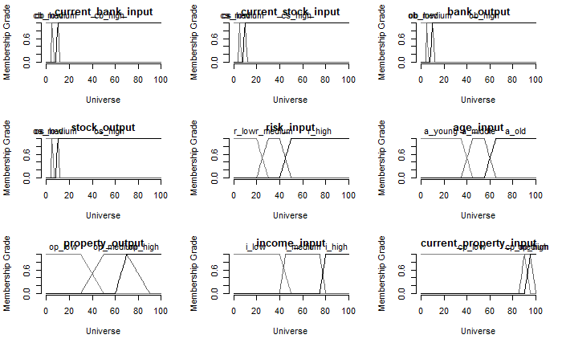

```r
plot(stock_system)
```

# Test Cases for Property

Test Stock Rule #1 - age young, income low then investment in property low

```r
fi <- fuzzy_inference(property_system, list(age_input = 25, income_input = 30))
plot(fi)
```

```r
gset_defuzzify(fi,"centroid")
```

```
[1] 20.16049
```

Test Stock Rule #2 - age young, income medium then investment in property medium

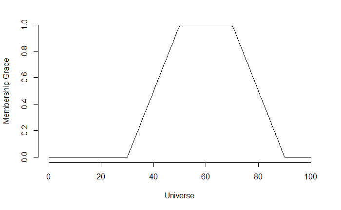

```r
fi <- fuzzy_inference(property_system, list(age_input = 25, income_input = 50))
plot(fi)
```

```r
gset_defuzzify(fi,"centroid")
```

```
[1] 60
```

Test Stock Rule #3 - age young, income high then investment in property high

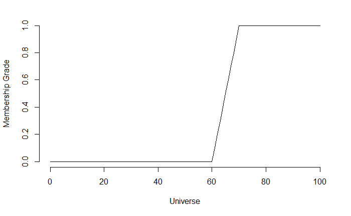

```r
fi <- fuzzy_inference(property_system, list(age_input = 25, income_input = 80))
plot(fi)
```

```r
gset_defuzzify(fi,"centroid")
```

```
[1] 82.6338
```

Test Stock Rule #4 - age middle, income low then investment in property low

```r
fi <- fuzzy_inference(property_system, list(age_input = 47, income_input = 30))
plot(fi)
```

```r
gset_defuzzify(fi,"centroid")
```

```
[1] 20.16049
```

Test Stock Rule #5 - age middle, income medium then investment in property low

```r
fi <- fuzzy_inference(property_system, list(age_input = 47, income_input = 50))
plot(fi)
```

```r
gset_defuzzify(fi,"centroid")
```

```
[1] 20.16049
```

Test Stock Rule #6 - age middle, income high then investment in property medium

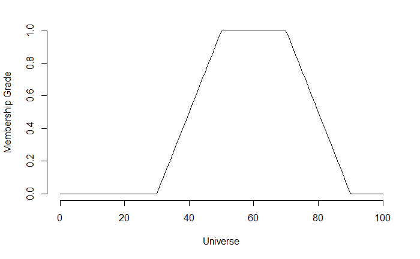

```r
fi <- fuzzy_inference(property_system, list(age_input = 47, income_input = 80))
plot(fi)
```

```r
gset_defuzzify(fi,"centroid")
```

```
[1] 60
```

Test Stock Rule #7 - age old, income high then investment in property low

```r
fi <- fuzzy_inference(property_system, list(age_input = 70, income_input = 80))
plot(fi)
```

```r
gset_defuzzify(fi,"centroid")
```

```
[1] 20.16049
```

# Test Cases for Stock

Test Stock Rule #1 - age young, income low, risk appetite low then investment in stock low

```r
fi <- fuzzy_inference(stock_system, list(age_input = 25, income_input = 30, risk_input = 10), implication = "minimum")
plot(fi)
```

```r
gset_defuzzify(fi,"centroid")
```

```
[1] 2.769231
```

Test Stock Rule #2 - age young, income low, risk appetite medium then investment in stock low

```r
fi <- fuzzy_inference(stock_system, list(age_input = 25, income_input = 30, risk_input = 35), implication = "minimum")
plot(fi)
```

```r
gset_defuzzify(fi,"centroid")
```

```
[1] 2.769231
```

```r
fi <- fuzzy_inference(stock_system, list(age_input = 25, income_input = 30, risk_input = 60), implication = "minimum")
plot(fi)
```

```r
gset_defuzzify(fi,"centroid")
```

```
[1] 7.769231
```

Test Stock Rule #4 - age young, income medium, risk appetite low then investment in stock low

```r
fi <- fuzzy_inference(stock_system, list(age_input = 25, income_input = 50, risk_input = 10), implication = "minimum")
plot(fi)
```

```r
gset_defuzzify(fi,"centroid")
```

```
[1] 2.769231
```

```r
fi <- fuzzy_inference(stock_system, list(age_input = 25, income_input = 50, risk_input = 35), implication = "minimum")
plot(fi)
```

```r
gset_defuzzify(fi,"centroid")
```

```
[1] 7.769231
```

```r
fi <- fuzzy_inference(stock_system, list(age_input = 25, income_input = 50, risk_input = 60), implication = "minimum")
plot(fi)
```

```r
gset_defuzzify(fi,"centroid")
```

```
[1] 54.74863
```

Test Stock Rule #7 - age young, income high, risk appetite low then investment in stock low

```r
fi <- fuzzy_inference(stock_system, list(age_input = 25, income_input = 80, risk_input = 10), implication = "minimum")
plot(fi)
```

```r
gset_defuzzify(fi,"centroid")
```

```
[1] 2.769231
```

```r
fi <- fuzzy_inference(stock_system, list(age_input = 25, income_input = 80, risk_input = 35), implication = "minimum")
plot(fi)
```

```r
gset_defuzzify(fi,"centroid")
```

```
[1] 7.769231
```

```r
fi <- fuzzy_inference(stock_system, list(age_input = 25, income_input = 80, risk_input = 60), implication = "minimum")
plot(fi)
```

```r
gset_defuzzify(fi,"centroid")
```

```
[1] 54.74863
```

Test Stock Rule #10 - age middle, income low, risk appetite low then investment in stock low

```r
fi <- fuzzy_inference(stock_system, list(age_input = 50, income_input = 30, risk_input = 10), implication = "minimum")
plot(fi)
```

```r
gset_defuzzify(fi,"centroid")
```

```
[1] 2.769231
```

Test Stock Rule #11 - age middle, income low, risk appetite medium then investment in stock low

```r
fi <- fuzzy_inference(stock_system, list(age_input = 50, income_input = 30, risk_input = 35), implication = "minimum")
plot(fi)
```

```r
gset_defuzzify(fi,"centroid")
```

```
[1] 2.769231
```

Test Stock Rule #12 - age middle, income low, risk appetite high then investment in stock low

```r
fi <- fuzzy_inference(stock_system, list(age_input = 50, income_input = 30, risk_input = 60), implication = "minimum")
plot(fi)
```

```r
gset_defuzzify(fi,"centroid")
```

```
[1] 2.769231
```

Test Stock Rule #13 - age middle, income medium, risk appetite low then investment in stock low

```r
fi <- fuzzy_inference(stock_system, list(age_input = 50, income_input = 50, risk_input = 10), implication = "minimum")
plot(fi)
```

```r
gset_defuzzify(fi,"centroid")
```

```
[1] 2.769231
```

Test Stock Rule #14 - age middle, income medium, risk appetite medium then investment in stock low

```r
fi <- fuzzy_inference(stock_system, list(age_input = 50, income_input = 50, risk_input = 35), implication = "minimum")
plot(fi)
```

```r
gset_defuzzify(fi,"centroid")
```

```
[1] 2.769231
```

```r
fi <- fuzzy_inference(stock_system, list(age_input = 50, income_input = 50, risk_input = 60), implication = "minimum")
plot(fi)
```

```r
gset_defuzzify(fi,"centroid")
```

```
[1] 7.769231
```

Test Stock Rule #16 - age middle, income high, risk appetite low then investment in stock low

```r
fi <- fuzzy_inference(stock_system, list(age_input = 50, income_input = 80, risk_input = 10), implication = "minimum")
plot(fi)
```

```r
gset_defuzzify(fi,"centroid")
```

```
[1] 2.769231
```

```r
fi <- fuzzy_inference(stock_system, list(age_input = 50, income_input = 80, risk_input = 35), implication = "minimum")
plot(fi)
```

```r
gset_defuzzify(fi,"centroid")
```

```
[1] 7.769231
```

```r
fi <- fuzzy_inference(stock_system, list(age_input = 50, income_input = 80, risk_input = 60), implication = "minimum")
plot(fi)
```

```r
gset_defuzzify(fi,"centroid")
```

```
[1] 54.74863
```

Test Stock Rule #19 - age old, income low, risk appetite low then investment in stock low

```r
fi <- fuzzy_inference(stock_system, list(age_input = 70, income_input = 30, risk_input = 10), implication = "minimum")
plot(fi)
```

```r
gset_defuzzify(fi,"centroid")
```

```
[1] 2.769231
```

Test Stock Rule #20 - age old, income low, risk appetite medium then investment in stock low

```r
fi <- fuzzy_inference(stock_system, list(age_input = 70, income_input = 30, risk_input = 35), implication = "minimum")
plot(fi)
```

```r
gset_defuzzify(fi,"centroid")
```

```
[1] 2.769231
```

Test Stock Rule #21 - age old, income low, risk appetite high then investment in stock low

```r
fi <- fuzzy_inference(stock_system, list(age_input = 70, income_input = 30, risk_input = 60), implication = "minimum")
plot(fi)
```

```r
gset_defuzzify(fi,"centroid")
```

```
[1] 2.769231
```

Test Stock Rule #22 - age old, income medium, risk appetite low then investment in stock low

```r
fi <- fuzzy_inference(stock_system, list(age_input = 70, income_input = 50, risk_input = 10), implication = "minimum")
plot(fi)
```

```r
gset_defuzzify(fi,"centroid")
```

```
[1] 2.769231
```

Test Stock Rule #23 - age old, income medium, risk appetite medium then investment in stock low

```r
fi <- fuzzy_inference(stock_system, list(age_input = 70, income_input = 50, risk_input = 35), implication = "minimum")
plot(fi)
```

```r
gset_defuzzify(fi,"centroid")
```

```
[1] 2.769231
```

Test Stock Rule #24 - age old, income medium, risk appetite high then investment in stock low

```r
fi <- fuzzy_inference(stock_system, list(age_input = 70, income_input = 50, risk_input = 60), implication = "minimum")
plot(fi)
```

```r
gset_defuzzify(fi,"centroid")
```

```
[1] 2.769231
```

Test Stock Rule #25 - age old, income high, risk appetite low then investment in stock low

```r
fi <- fuzzy_inference(stock_system, list(age_input = 70, income_input = 80, risk_input = 10), implication = "minimum")
plot(fi)
```

```r
gset_defuzzify(fi,"centroid")
```

```
[1] 2.769231
```

Test Stock Rule #26 - age old, income high, risk appetite medium then investment in stock low

```r
fi <- fuzzy_inference(stock_system, list(age_input = 70, income_input = 80, risk_input = 35), implication = "minimum")
plot(fi)
```

```r
gset_defuzzify(fi,"centroid")
```

```
[1] 2.769231
```

```r
fi <- fuzzy_inference(stock_system, list(age_input = 70, income_input = 80, risk_input = 60), implication = "minimum")
plot(fi)
```

```r
gset_defuzzify(fi,"centroid")
```

```
[1] 7.769231
```

# Boundary cases - between young and middle

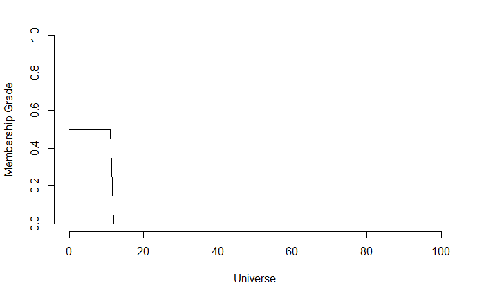

```r
fi <- fuzzy_inference(stock_system, list(age_input = 40, income_input = 30, risk_input = 60), implication = "minimum")
plot(fi)
```

```r
gset_defuzzify(fi,"centroid")
```

```
[1] 5.5
```

Test Stock Rule #29 - age between young and middle, income low, risk appetite high then investment in stock low

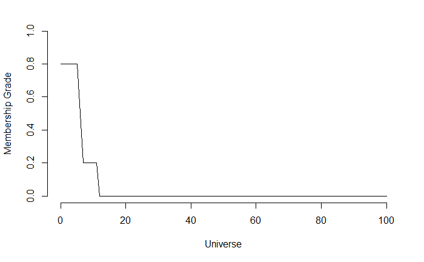

```r
fi <- fuzzy_inference(stock_system, list(age_input = 43, income_input = 30, risk_input = 60), implication = "minimum")
plot(fi)
```

```r
gset_defuzzify(fi,"centroid")
```

```
[1] 3.809524
```

```r
fi <- fuzzy_inference(stock_system, list(age_input = 45, income_input = 30, risk_input = 60), implication = "minimum")
plot(fi)
```

```r
gset_defuzzify(fi,"centroid")
```

```
[1] 2.769231
```

# Boundary cases - between low and medium income

```r
fi <- fuzzy_inference(stock_system, list(age_input = 25, income_input = 38, risk_input = 60), implication = "minimum")
plot(fi)
```

```r
gset_defuzzify(fi,"centroid")
```

```
[1] 7.769231
```

```r
fi <- fuzzy_inference(stock_system, list(age_input = 25, income_input = 40, risk_input = 60), implication = "minimum")
plot(fi)
```

```r
gset_defuzzify(fi,"centroid")
```

```
[1] 7.769231
```

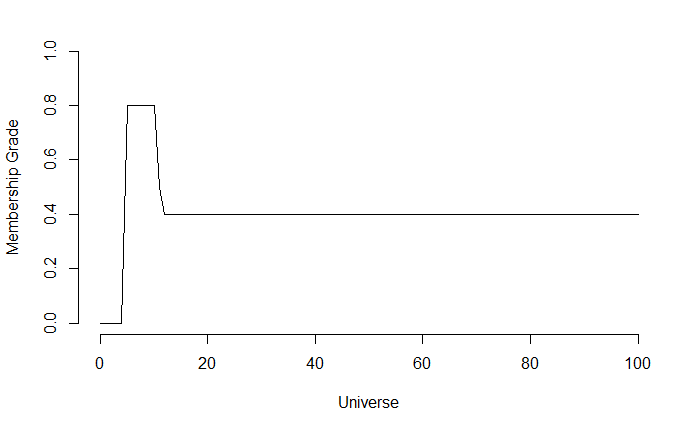

```r
fi <- fuzzy_inference(stock_system, list(age_input = 25, income_input = 42, risk_input = 60), implication = "minimum")
plot(fi)
```

```r
gset_defuzzify(fi,"centroid")
```

```
[1] 49.75795
```

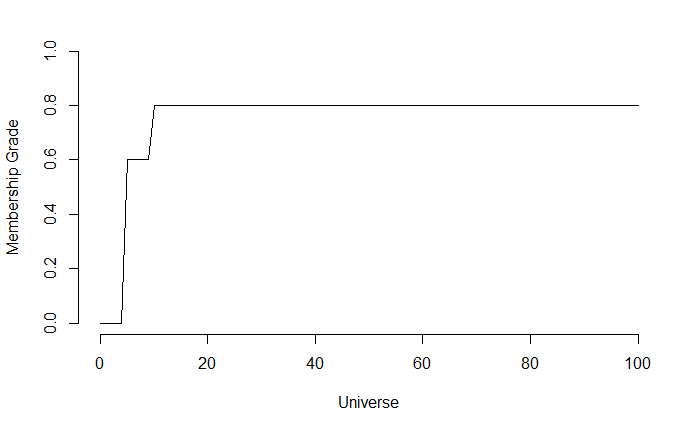

```r
fi <- fuzzy_inference(stock_system, list(age_input = 25, income_input = 44, risk_input = 60), implication = "minimum")
plot(fi)
```

```r
gset_defuzzify(fi,"centroid")
```

```
[1] 53.10026
```

# Boundary cases - between medium and high risk appetite

Test Stock Rule #35 - age old, income high, risk appetite medium then investment in stock low

```r
fi <- fuzzy_inference(stock_system, list(age_input = 70, income_input = 80, risk_input = 40), implication = "minimum")
plot(fi)
```

```r
gset_defuzzify(fi,"centroid")
```

```
[1] 2.769231
```

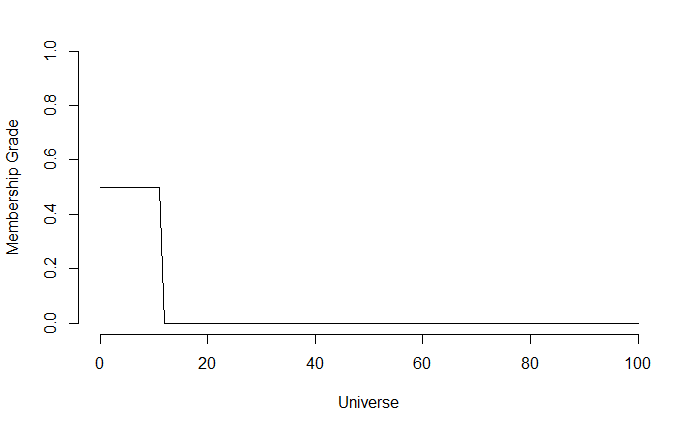

```r
fi <- fuzzy_inference(stock_system, list(age_input = 70, income_input = 80, risk_input = 45), implication = "minimum")
plot(fi)
```

```r
gset_defuzzify(fi,"centroid")
```

```
[1] 5.5
```

```r
fi <- fuzzy_inference(stock_system, list(age_input = 70, income_input = 80, risk_input = 50), implication = "minimum")
plot(fi)
```

```r
gset_defuzzify(fi,"centroid")
```

```
[1] 7.769231
```

```r
fi <- fuzzy_inference(stock_system, list(age_input = 70, income_input = 80, risk_input = 55), implication = "minimum")
plot(fi)
```

```r
gset_defuzzify(fi,"centroid")
```

```
[1] 7.769231
```